# Lesson 5 - Probabilistic Grammar

02/06/2019

## Language Topics Discussed

- Grammatical slots part 2!
- Understanding word choice based on contextual features

## Synonyms

- How do we decide which word to use when we have multiple words that share the same meaning?
- I ____ to go to the mall this week.
  - Planned
  - Decided
  - Scheduled
  - am going to go
- She is very _____.
  - Pretty
  - Beautiful
  - Alluring

## More examples

- May versus might: depending on certainty
- Gown versus dress: formality in social situation
- Soda versus coke versus pop: cultural factors

## Causative Constructions

- Phrases like: might/have/get/cause X to do Y
- Combines conjugated ‘to have’ or ‘to get’ + direct object + main verb
- When one does not carry out an action oneself but rather has the action done by someone else
- I *had* him *paint* my house.
- Causee is the actor, does the action
- Causer is the person/thing who required the action

## Causative Constructions

- Do versus let in Dutch
- Do appears to be a direct causation
  - “If the energy is put in, the result is inevitable”
  - He reminded me of my father (causation is involuntary)
- Let appears to be an indirect causation
  - Enablement and permission
  - I let him paint my house

## Cause for Cause

- Verb:
  - State or action: does it apply to state verbs or action verbs
  - Transitivity: why types of verbs, transitive, intransitive or both?

## Cause for Cause

- The action being caused:
  - Control: does the causee have control?
  - Volition: does the causee act willingly?
  - Affectedness: how is the causee affected?

## Cause for Cause

- Related to the causer:
  - Directness: of the causer
  - Intention: accidental or intentional
  - Natural: natural activity or with effort
  - Involvement: the causer’s involvement in activity

## Logistic Regression

Original regression model examining a continuous outcome measure y:

\[{\hat{y_i}} = b_0 + b_1x_{1i} + b_2x_{2i} ... + \epsilon_i\] Logistic regression model examining a categorical outcome measure y:

\[g(y) = b_0 + b_1x_{1i} + b_2x_{2i} ... + \epsilon_i\]

## Logistic Regression

- Main distinction is g(y): which is the logit or log odds of the outcome.
- Two options: binomial logistic regression
- More than two options: multinomial or polytomous regression
- g(y) represents the odds of one choice over another.

## Logistic Regression

- Otherwise, information is the same:
  - \(b_0\): intercept, chances of outcome when all predictors are zero
  - \(b_1\): slope for one X variable, coefficient
  - … etc. But we will also add better interpretation for the predictors to help understand likelihood of outcome (i.e., since the data is categorical)

## Requirements for Logistic Regression

- Large enough sample size for the outcome variable
- How big?

```r
library(Rling)
data("doenLaten")
table(doenLaten$Aux)
```

```
##
## laten  doen
##   277   178
```

## Running a Binary Logistic Regression

```r
#install.packages("rms") #if you have not used it before
library(rms)
#you can also use glm() for log regression but rms has cool options
head(doenLaten)
```

```
##     Aux Country  Causation EPTrans EPTrans1
## 1 laten      NL   Inducive    Intr     Intr
## 2 laten      NL   Physical    Intr     Intr
## 3 laten      NL   Inducive      Tr       Tr
## 4  doen      BE  Affective    Intr     Intr
## 5 laten      NL   Inducive      Tr       Tr
## 6 laten      NL Volitional    Intr     Intr
```

## Run your model!

```r
model = lrm(Aux ~ Causation + EPTrans + Country, #model formula like lm()
            data = doenLaten)
model
```

```
## Logistic Regression Model
##
##  lrm(formula = Aux ~ Causation + EPTrans + Country, data = doenLaten)
##
##                        Model Likelihood     Discrimination    Rank Discrim.
##                           Ratio Test           Indexes           Indexes
##  Obs           455    LR chi2     271.35    R2       0.609    C       0.894
##   laten        277    d.f.             5    g        2.296    Dxy     0.787
##   doen         178    Pr(> chi2) <0.0001    gr       9.935    gamma   0.817
##  max |deriv| 1e-07                          gp       0.378    tau-a   0.376
##                                             Brier    0.112
##
##                       Coef    S.E.   Wald Z Pr(>|Z|)
##  Intercept             1.8631 0.3771  4.94  <0.0001
##  Causation=Inducive   -3.3725 0.3741 -9.01  <0.0001
##  Causation=Physical    0.4661 0.6275  0.74  0.4576
##  Causation=Volitional -3.7373 0.4278 -8.74  <0.0001
##  EPTrans=Tr           -1.2952 0.3394 -3.82  0.0001
##  Country=BE            0.7085 0.2841  2.49  0.0126
##
```

## Frequency

- Important for data screening

```r
model$freq
```

```
## laten  doen
##   277   178
```

## Overall Predictiveness

- Likelihood ratio test = \(\chi^2\) test
- Similar to the F-test in regression
- \(\chi^2\)(5) = 271.35, p < .001
- Compared to a model of no predictors, should have less error (deviance)

```r
model$stats
```

```
##               Obs         Max Deriv        Model L.R.              d.f.
## 455.0000000000000   0.0000001119568 271.3508063697709   5.0000000000000
##                 P                 C               Dxy             Gamma
##   0.0000000000000   0.8936539163591   0.7873078327181   0.8171560888328
##             Tau-a                R2             Brier                 g
##   0.3758435397202   0.6088475272089   0.1116057213797   2.2960539041912
##                gr                gp
##   9.9349009305359   0.3782199942877
```

## Goodness of Fit

- Effect size of how well the model fit the data
- \(R^2\) - much like regression, albeit more difficult to interpret.
  - In the output that’s Nagelkerke’s pseudo-\(R^2\)

```r
model$stats
```

```
##               Obs         Max Deriv        Model L.R.              d.f.
## 455.0000000000000   0.0000001119568 271.3508063697709   5.0000000000000
##                 P                 C               Dxy             Gamma
##   0.0000000000000   0.8936539163591   0.7873078327181   0.8171560888328
##             Tau-a                R2             Brier                 g
##   0.3758435397202   0.6088475272089   0.1116057213797   2.2960539041912
##                gr                gp
##   9.9349009305359   0.3782199942877
```

## Goodness of Fit

- Concordance index C
  - For each \(Y_i\), a probability of the outcome is created
  - C is the number of times that the probability of the outcome matches the actual outcome
- Interpretation:
  - < .5: no discrimination
  - .7 <= C < .8: acceptable
  - .8 <= C < .9: excellent
  - <= .9 outstanding

## Coefficients

- Under Coef, these are represented as log odds
- Odds ratios are centered around one (like 6 to 1, 4 to 1)
- Log odds ratio are centered around zero
  - Positive numbers indicate a higher probability for the coded group
  - Negative numbers indicate a higher probability for the comparison group
- What is coded versus comparison?

```r
levels(doenLaten$Aux)
```

```
## [1] "laten" "doen"
```

## Coefficients

```r
#model
 #                      Coef    S.E.   Wald Z Pr(>|Z|)
 # Intercept             1.8631 0.3771  4.94  <0.0001
 # Causation=Inducive   -3.3725 0.3741 -9.01  <0.0001
 # Causation=Physical    0.4661 0.6275  0.74  0.4576
 # Causation=Volitional -3.7373 0.4278 -8.74  <0.0001
 # EPTrans=Tr           -1.2952 0.3394 -3.82  0.0001
 # Country=BE            0.7085 0.2841  2.49  0.0126
```

## Coefficients

```r
 # Causation=Inducive   -3.3725 0.3741 -9.01  <0.0001
 # Causation=Physical    0.4661 0.6275  0.74  0.4576
 # Causation=Volitional -3.7373 0.4278 -8.74  <0.0001

table(doenLaten$Aux, doenLaten$Causation)
```

```
##
##         Affective Inducive Physical Volitional
##   laten        15      160        4         98
##   doen         75       25       59         19
```

## Coefficients

```r
 # EPTrans=Tr           -1.2952 0.3394 -3.82  0.0001
 # Country=BE            0.7085 0.2841  2.49  0.0126

table(doenLaten$Aux, doenLaten$EPTrans)
```

```
##
##         Intr  Tr
##   laten  137 140
##   doen   144  34
```

```r
table(doenLaten$Aux, doenLaten$Country)
```

```
##
##          NL  BE
##   laten 162 115
##   doen   71 107
```

## Interactions

```r
model1 = glm(Aux ~ Causation + EPTrans + Country, #model formula like lm()
             family = binomial,
             data = doenLaten)
model2 = glm(Aux ~ Causation + EPTrans*Country, #model formula like lm()
             family = binomial,
             data = doenLaten)
anova(model1, model2, test = "Chisq")
```

```
## Analysis of Deviance Table
##
## Model 1: Aux ~ Causation + EPTrans + Country
## Model 2: Aux ~ Causation + EPTrans * Country
##   Resid. Df Resid. Dev Df Deviance Pr(>Chi)
## 1       449     337.70
## 2       448     334.58  1   3.1151  0.07757 .
## ---
## Signif. codes:  0 '***' 0.001 '**' 0.01 '*' 0.05 '.' 0.1 ' ' 1
```

## Interactions

```r
#summary(model2)
# Coefficients:
#                     Estimate Std. Error z value             Pr(>|z|)
# (Intercept)           2.0991     0.4079   5.146          0.000000267 ***
# CausationInducive    -3.4463     0.3892  -8.854 < 0.0000000000000002 ***
# CausationPhysical     0.3898     0.6336   0.615              0.53839
# CausationVolitional  -3.7795     0.4364  -8.661 < 0.0000000000000002 ***
# EPTransTr            -1.8825     0.4919  -3.827              0.00013 ***
# CountryBE             0.3693     0.3416   1.081              0.27966
# EPTransTr:CountryBE   1.0827     0.6215   1.742              0.08149 .
```

## Interactions

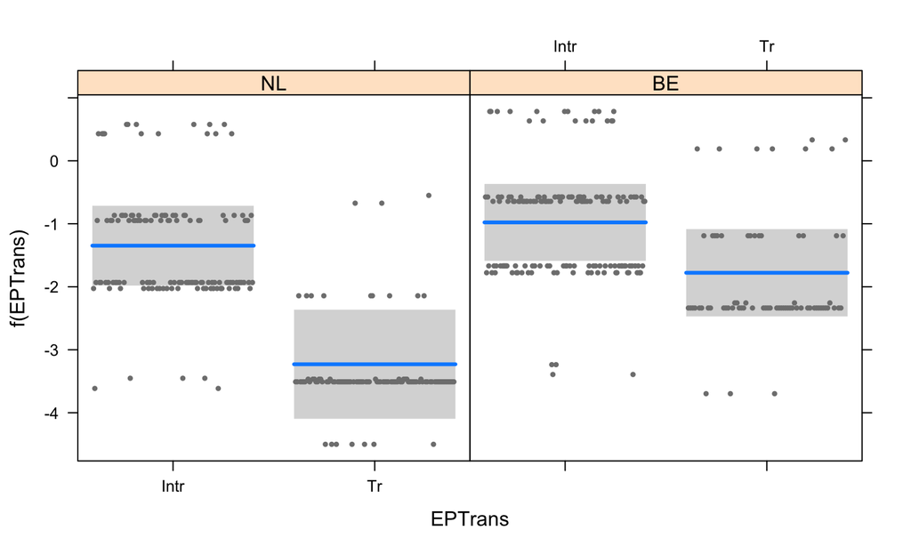

```r
library(visreg)
visreg(model2, "EPTrans", by = "Country")
```

## Outliers

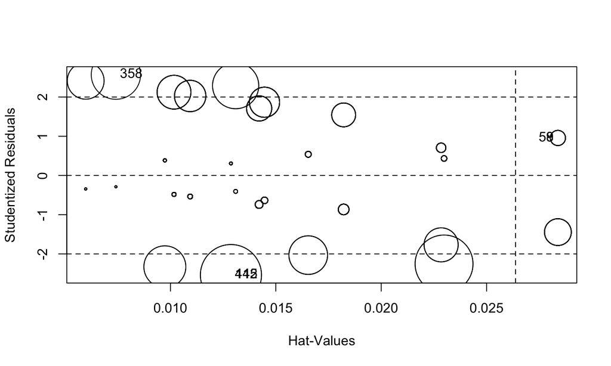

```
##        StudRes         Hat       CookD
## 8    0.9562967 0.028382692 0.002839675
## 59   0.9562967 0.028382692 0.002839675
## 142 -2.5378871 0.012870299 0.045911281
## 358  2.5688214 0.007412518 0.029835538
## 415 -2.5378871 0.012870299 0.045911281
```

```r
library(car)
influencePlot(model1)
```

## Assumptions

- Observations are independent
- No multicollinearity (remember VIF > 5 or 10 is bad)
- Overprediction (complete/quasi complete separation)

```r
rms::vif(model) #use the rms:: to distinguish between car::vif and rms::vif
```

```
##   Causation=Inducive   Causation=Physical Causation=Volitional
##             1.699064             1.356411             1.959948
##           EPTrans=Tr           Country=BE
##             1.270669             1.017354
```

## Summary

- We can model word choice with various predictors by using logistic regression with two outcomes.
  - You can extend that to multinomial logistic regression with `mlogit`
  - https://www.youtube.com/watch?v=c78eMWw43I0 is a tutorial from Dr. B (if you are interested for your final project)
- You learned how to run and use a logistic regression, along with assumptions checks and understanding the output